# Differential expression analysis

Min-Yao

2025-09-28

```r
library(monocle3)
```

```r
# The tutorial shown below and on subsequent pages uses two additional packages:
library(ggplot2)
library(dplyr)
set.seed(2025)
```

```r
expression_matrix <- readRDS(url("https://depts.washington.edu:/trapnell-lab/software/monocle3/celegans/data/packer_embryo_expression.rds"))
cell_metadata <- readRDS(url("https://depts.washington.edu:/trapnell-lab/software/monocle3/celegans/data/packer_embryo_colData.rds"))
gene_annotation <- readRDS(url("https://depts.washington.edu:/trapnell-lab/software/monocle3/celegans/data/packer_embryo_rowData.rds"))

cds <- new_cell_data_set(expression_matrix,
                         cell_metadata = cell_metadata,
                         gene_metadata = gene_annotation)
```

Differential gene expression analysis is a common task in RNA-Seq experiments. Monocle can help you find genes that are differentially expressed between groups of cells and assesses the statistical signficance of those changes. Monocle 3 includes a powerful system for finding genes that vary across cells of different types, were collected at different developmental time points, or that have been perturbed in different ways.

There are two approaches for differential analysis in Monocle:

Regression analysis: using fit_models(), you can evaluate whether each gene depends on variables such as time, treatments, etc. Graph-autocorrelation analysis: using graph_test(), you can find genes that vary over a trajectory or between clusters. Monocle also comes with specialized functions for finding co-regulated modules of differentially expressed genes. Monocle also allows you to interactively interrogate specific clusters or regions of a trajectory (e.g. branch points) for genes that vary within them.

Let’s examine these tools in turn.

# Regression analysis

In this section, we’ll explore how to use Monocle to find genes that are differentially expressed according to several different criteria. Performing differential expression analysis on all genes in a cell_data_set object can take anywhere from minutes to hours, depending on how complex the analysis is. To keep the vignette simple and fast, we’ll be working with small sets of genes. Rest assured, however, that Monocle can analyze several thousands of genes even in large experiments, making it useful for discovering dynamically regulated genes during the biological process you’re studying.

Let’s begin with a small set of genes that we know are important in ciliated neurons to demonstrate Monocle’s capabilities:

```r
ciliated_genes <- c("che-1",
                    "hlh-17",
                    "nhr-6",
                    "dmd-6",
                    "ceh-36",
                    "ham-1")
cds_subset <- cds[rowData(cds)$gene_short_name %in% ciliated_genes,]
```

The differential analysis tools in Monocle are extremely flexible. Monocle works by fitting a regression model to each gene. You can specify this model to account for various factors in your experiment (time, treatment, and so on). For example, In the embryo data, the cells were collected at different time points. We can test whether any of the genes above change over time in their expression by first fitting a generalized linear model to each one:

To do so, we first call the fit_models() function:

```r
gene_fits <- fit_models(cds_subset, model_formula_str = "~embryo.time")
summary(gene_fits)
```

```
##       id            gene_short_name    num_cells_expressed   gene_id
##  Length:6           Length:6           Min.   :  51.0      Length:6
##  Class :character   Class :character   1st Qu.: 172.8      Class :character
##  Mode  :character   Mode  :character   Median : 582.5      Mode  :character
##                                        Mean   : 681.7
##                                        3rd Qu.:1060.5
##                                        Max.   :1618.0
##  model.Length  model.Class  model.Mode
##  26        speedglm  list
##  26        speedglm  list
##  26        speedglm  list
##  26        speedglm  list
##  26        speedglm  list
##  26        speedglm  list
##  model_summary.Length  model_summary.Class  model_summary.Mode
##  21                summary.speedglm  list
##  21                summary.speedglm  list
##  21                summary.speedglm  list
##  21                summary.speedglm  list
##  21                summary.speedglm  list
##  21                summary.speedglm  list
##     status
##  Length:6
##  Class :character
##  Mode  :character
##
##
##
```

Now let’s see which of these genes have time-dependent expression. First, we extract a table of coefficients from each model using the coefficient_table() function:

```r
fit_coefs <- coefficient_table(gene_fits)
fit_coefs
```

```
## # A tibble: 12 × 15
##    id       gene_short_name num_cells_expressed gene_id model      model_summary
##    <chr>    <chr>                         <int> <chr>   <named li> <named list>
##  1 WBGene0… ham-1                          1618 WBGene… <speedglm> <smmry.sp>
##  2 WBGene0… ham-1                          1618 WBGene… <speedglm> <smmry.sp>
##  3 WBGene0… dmd-6                           873 WBGene… <speedglm> <smmry.sp>
##  4 WBGene0… dmd-6                           873 WBGene… <speedglm> <smmry.sp>
##  5 WBGene0… hlh-17                           51 WBGene… <speedglm> <smmry.sp>
##  6 WBGene0… hlh-17                           51 WBGene… <speedglm> <smmry.sp>
##  7 WBGene0… nhr-6                           133 WBGene… <speedglm> <smmry.sp>
##  8 WBGene0… nhr-6                           133 WBGene… <speedglm> <smmry.sp>
##  9 WBGene0… ceh-36                         1123 WBGene… <speedglm> <smmry.sp>
## 10 WBGene0… ceh-36                         1123 WBGene… <speedglm> <smmry.sp>
## 11 WBGene0… che-1                           292 WBGene… <speedglm> <smmry.sp>
## 12 WBGene0… che-1                           292 WBGene… <speedglm> <smmry.sp>
## # ℹ 9 more variables: status <chr>, term <chr>, estimate <dbl>, std_err <dbl>,
## #   test_val <dbl>, p_value <dbl>, normalized_effect <dbl>,
## #   model_component <chr>, q_value <dbl>
```

Note that the table includes one row for each term of each gene’s model. We generally don’t care about the intercept term, so we can easily just extract the time terms:

```r
emb_time_terms <- fit_coefs %>% filter(term == "embryo.time")
emb_time_terms
```

```
## # A tibble: 6 × 15
##   id        gene_short_name num_cells_expressed gene_id model      model_summary
##   <chr>     <chr>                         <int> <chr>   <named li> <named list>
## 1 WBGene00… ham-1                          1618 WBGene… <speedglm> <smmry.sp>
## 2 WBGene00… dmd-6                           873 WBGene… <speedglm> <smmry.sp>
## 3 WBGene00… hlh-17                           51 WBGene… <speedglm> <smmry.sp>
## 4 WBGene00… nhr-6                           133 WBGene… <speedglm> <smmry.sp>
## 5 WBGene00… ceh-36                         1123 WBGene… <speedglm> <smmry.sp>
## 6 WBGene00… che-1                           292 WBGene… <speedglm> <smmry.sp>
## # ℹ 9 more variables: status <chr>, term <chr>, estimate <dbl>, std_err <dbl>,
## #   test_val <dbl>, p_value <dbl>, normalized_effect <dbl>,
## #   model_component <chr>, q_value <dbl>
```

Now, let’s pull out the genes that have a significant time component. coefficient_table() tests whether each coefficient differs significantly from zero under the Wald test. By default, coefficient_table() adjusts these p-values for multiple hypothesis testing using the method of Benjamini and Hochberg. These adjusted values can be found in the q_value column. We can filter the results and control the false discovery rate as follows:

```r
emb_time_terms %>% filter (q_value < 0.05) %>%
         select(gene_short_name, term, q_value, estimate)
```

```
## # A tibble: 5 × 4
##   gene_short_name term          q_value estimate
##   <chr>           <chr>           <dbl>    <dbl>
## 1 ham-1           embryo.time 4.59e- 73 -0.00388
## 2 dmd-6           embryo.time 2.03e-255  0.00750
## 3 hlh-17          embryo.time 2.47e-  3  0.00334
## 4 nhr-6           embryo.time 8.41e- 28  0.00579
## 5 ceh-36          embryo.time 1.45e- 34  0.00279
```

We can see that five of the six genes significantly vary as a function of time.

Monocle also provides some easy ways to plot the expression of a small set of genes grouped by the factors you use during differential analysis. This helps you visualize the differences revealed by the tests above. One type of plot is a “violin” plot.

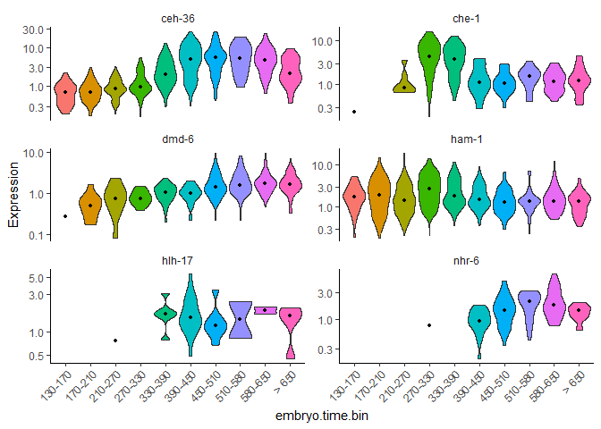

```r
plot_genes_violin(cds_subset, group_cells_by="embryo.time.bin", ncol=2) +
      theme(axis.text.x=element_text(angle=45, hjust=1))
```

By default, the violin plot log-scales the expression, which drops cells with zero expression, resulting in potentially misleading figures. The Monocle3 develop branch has a hybrid plot where cells appear as red dots in a Sina plot and the cell distribution appears as a histogram with green bars and a blue median_qi interval.

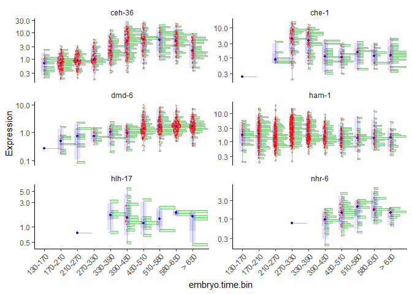

```r
plot_genes_hybrid(cds_subset, group_cells_by="embryo.time.bin", ncol=2) +
      theme(axis.text.x=element_text(angle=45, hjust=1))
```

# Controlling for batch effects and other factors

```r
gene_fits <- fit_models(cds_subset, model_formula_str = "~embryo.time + batch")
fit_coefs <- coefficient_table(gene_fits)
fit_coefs %>% filter(term != "(Intercept)") %>%
      select(gene_short_name, term, q_value, estimate)
```

```
## # A tibble: 42 × 4
##    gene_short_name term                                 q_value estimate
##    <chr>           <chr>                                  <dbl>    <dbl>
##  1 ham-1           embryo.time                        3.65e- 27 -0.00276
##  2 ham-1           batchWaterston_400_minutes         2.28e-  3  0.212
##  3 ham-1           batchWaterston_500_minutes_batch_1 5.35e-  3 -0.357
##  4 ham-1           batchWaterston_500_minutes_batch_2 4.24e-  9 -1.40
##  5 ham-1           batchMurray_r17                    7.02e-  1  0.0932
##  6 ham-1           batchMurray_b01                    2.34e-  1 -0.187
##  7 ham-1           batchMurray_b02                    1.68e-  1 -0.451
##  8 dmd-6           embryo.time                        2.61e-150  0.00713
##  9 dmd-6           batchWaterston_400_minutes         1.08e-  6  2.18
## 10 dmd-6           batchWaterston_500_minutes_batch_1 3.28e- 12  3.00
## # ℹ 32 more rows
```

# Evaluating models of gene expression

How good are these models at “explaining” gene expression? We can evaluate the fits of each model using the evaluate_fits() function:

```r
evaluate_fits(gene_fits)
```

```
## # A tibble: 6 × 12
##   id    gene_short_name num_cells_expressed gene_id status null_deviance df_null
##   <chr> <chr>                         <int> <chr>   <chr>          <dbl>   <int>
## 1 WBGe… ham-1                          1618 WBGene… OK            21030.    6187
## 2 WBGe… dmd-6                           873 WBGene… OK             6369.    6187
## 3 WBGe… hlh-17                           51 WBGene… OK              642.    6187
## 4 WBGe… nhr-6                           133 WBGene… OK             1660.    6187
## 5 WBGe… ceh-36                         1123 WBGene… OK            17972.    6187
## 6 WBGe… che-1                           292 WBGene… OK             8850.    6187
## # ℹ 5 more variables: logLik <lgl>, AIC <dbl>, BIC <dbl>, deviance <dbl>,
## #   df_residual <int>
```

Should we include the batch term in our model of gene expression or not? Monocle provides a function compare_models() that can help you decide. Compare models takes two models and returns the result of a likelihood ratio test between them. Any time you add terms to a model, it will improve the fit. But we should always to use the simplest model we can to explain our data. The likelihood ratio test helps us decide whether the improvement in fit is large enough to justify the complexity our extra terms introduce. You run compare_models() like this:

```r
time_batch_models <- fit_models(cds_subset,
                                model_formula_str = "~embryo.time + batch",
                                expression_family="negbinomial")
time_models <- fit_models(cds_subset,
                          model_formula_str = "~embryo.time",
                          expression_family="negbinomial")
compare_models(time_batch_models, time_models) %>% select(gene_short_name, q_value)
```

```
## # A tibble: 6 × 2
##   gene_short_name  q_value
##   <chr>              <dbl>
## 1 ham-1           4.46e-18
## 2 dmd-6           8.46e-50
## 3 hlh-17          2.48e- 6
## 4 nhr-6           7.09e- 5
## 5 ceh-36          3.84e-11
## 6 che-1           2.97e- 6
```

The first of the two models is called the full model. This model is essentially a way of predicting the expression value of each gene in a given cell knowing both what time it was collected and which batch of cells it came from. The second model, called the reduced model, does the same thing, but it only knows about the time each cell was collected. Because the full model has more information about each cell, it will do a better job of predicting the expression of the gene in each cell. The question Monocle must answer for each gene is how much better the full model’s prediction is than the reduced model’s. The greater the improvement that comes from knowing the batch of each cell, the more significant the result of the likelihood ratio test.

As we can see, all of the genes’ likelihood ratio tests are significant, indicating that there are substantial batch effects in the data. We are therefore justified in adding the batch term to our model.

# Choosing a distribution for modeling gene expression

Monocle uses generalized linear models to capture how a gene’s expression depends on each variable in the experiment. These models require you to specify a distribution that describes gene expression values. Most studies that use this approach to analyze their gene expression data use the negative binomial distribution, which is often appropriate for sequencing read or UMI count data. The negative binomial is at the core of many packages for RNA-seq analysis, such as DESeq2.

Likelihood based analysis and quasipoisson The quasi-poisson distribution doesn’t have a real likelihood function, so some of Monocle’s methods won’t work with it. Several of the columns in results tables from evaluate_fits() and compare_models() will be NA.

# Graph-autocorrelation analysis for comparing clusters

In the L2 worm data, we identified a number of clusters that were very distinct as neurons:

```r
# reload and reprocess the data as described in the 'Clustering and classifying your cells' section
expression_matrix <- readRDS(url("https://depts.washington.edu:/trapnell-lab/software/monocle3/celegans/data/cao_l2_expression.rds"))
cell_metadata <- readRDS(url("https://depts.washington.edu:/trapnell-lab/software/monocle3/celegans/data/cao_l2_colData.rds"))
gene_annotation <- readRDS(url("https://depts.washington.edu:/trapnell-lab/software/monocle3/celegans/data/cao_l2_rowData.rds"))

# Make the CDS object
cds <- new_cell_data_set(expression_matrix,
                         cell_metadata = cell_metadata,
                         gene_metadata = gene_annotation)
cds <- preprocess_cds(cds, num_dim = 100)
cds <- reduce_dimension(cds)
```

```
## No preprocess_method specified, using preprocess_method = 'PCA'
```

```r
cds <- cluster_cells(cds, resolution=1e-5)

colData(cds)$assigned_cell_type <- as.character(partitions(cds))
colData(cds)$assigned_cell_type <- dplyr::recode(colData(cds)$assigned_cell_type,
                                                 "1"="Body wall muscle",
                                                 "2"="Germline",
                                                 "3"="Motor neurons",
                                                 "4"="Seam cells",
                                                 "5"="Sex myoblasts",
                                                 "6"="Socket cells",
                                                 "7"="Marginal_cell",
                                                 "8"="Coelomocyte",
                                                 "9"="Am/PH sheath cells",
                                                 "10"="Ciliated neurons",
                                                 "11"="Intestinal/rectal muscle",
                                                 "12"="Excretory gland",
                                                 "13"="Chemosensory neurons",
                                                 "14"="Interneurons",
                                                 "15"="Unclassified eurons",
                                                 "16"="Ciliated neurons",
                                                 "17"="Pharyngeal gland cells",
                                                 "18"="Unclassified neurons",
                                                 "19"="Chemosensory neurons",
                                                 "20"="Ciliated neurons",
                                                 "21"="Ciliated neurons",
                                                 "22"="Inner labial neuron",
                                                 "23"="Ciliated neurons",
                                                 "24"="Ciliated neurons",
                                                 "25"="Ciliated neurons",
                                                 "26"="Hypodermal cells",
                                                 "27"="Mesodermal cells",
                                                 "28"="Motor neurons",
                                                 "29"="Pharyngeal gland cells",
                                                 "30"="Ciliated neurons",
                                                 "31"="Excretory cells",
                                                 "32"="Amphid neuron",
                                                 "33"="Pharyngeal muscle")
```

```
## No trajectory to plot. Has learn_graph() been called yet?
```

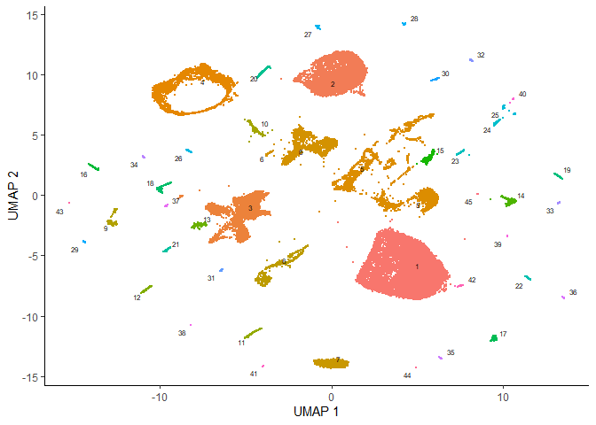

```r
plot_cells(cds, color_cells_by="partition")
```

Subset just the neurons:

```
## No trajectory to plot. Has learn_graph() been called yet?
```

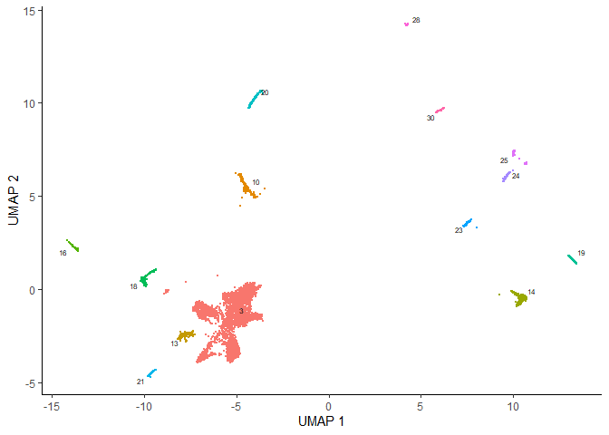

```r
neurons_cds <- cds[,grepl("neurons", colData(cds)$assigned_cell_type, ignore.case=TRUE)]
plot_cells(neurons_cds, color_cells_by="partition")
```

There are many subtypes of neurons, so perhaps the different neuron clusters correspond to different subtypes. To investigate which genes are expressed differentially across the clusters, we could use the regression analysis tools discussed above. However, Monocle provides an alternative way of finding genes that vary between groups of cells in UMAP space. The function graph_test() uses a statistic from spatial autocorrelation analysis called Moran’s I, which Cao & Spielmann et al showed to be effective in finding genes that vary in single-cell RNA-seq datasets.

You can run graph_test() like this:

```r
pr_graph_test_res <- graph_test(neurons_cds, neighbor_graph="knn", cores=1)
pr_deg_ids <- row.names(subset(pr_graph_test_res, q_value < 0.05))
```

The data frame pr_graph_test_res has the Moran’s I test results for each gene in the cell_data_set. If you’d like to rank the genes by effect size, sort this table by the morans_Icolumn, which ranges from -1 to +1. A value of 0 indicates no effect, while +1 indicates perfect positive autocorrelation and suggests that nearby cells have very similar values of a gene’s expression. Significant values much less than zero are generally rare.

Positive values indicate a gene is expressed in a focal region of the UMAP space (e.g. specific to one or more clusters). But how do we associate genes with clusters? The next section explains how to collect genes into modules that have similar patterns of expression and associate them with clusters.

# Finding modules of co-regulated genes

Once you have a set of genes that vary in some interesting way across the clusters, Monocle provides a means of grouping them into modules. You can call find_gene_modules(), which essentially runs UMAP on the genes (as opposed to the cells) and then groups them into modules using Louvain community analysis:

```r
gene_module_df <- find_gene_modules(neurons_cds[pr_deg_ids,], resolution=1e-2)
head(gene_module_df)
```

```
## # A tibble: 6 × 5
##   id             module supermodule  dim_1 dim_2
##   <chr>          <fct>  <fct>        <dbl> <dbl>
## 1 WBGene00000002 7      2           -3.05  -2.76
## 2 WBGene00000003 35     1            1.56   1.45
## 3 WBGene00000004 48     1           -0.133  3.12
## 4 WBGene00000006 39     1            0.699  2.12
## 5 WBGene00000013 52     6            3.27  -7.13
## 6 WBGene00000017 7      2           -2.89  -2.90
```

The data frame gene_module_df contains a row for each gene and identifies the module it belongs to. To see which modules are expressed in which clusters or partitions you can use two different approaches for visualization. The first is just to make a simple table that shows the aggregate expression of all genes in each module across all the clusters. Monocle provides a simple utility function called aggregate_gene_expression for this purpose:

```r
cell_group_df <- tibble::tibble(cell = row.names(colData(neurons_cds)),
                                cell_group = partitions(cds)[colnames(neurons_cds)])
head(cell_group_df)
```

```
## # A tibble: 6 × 2
##   cell                    cell_group
##   <chr>                   <fct>
## 1 cele-001-001.CATGACTCAA 3
## 2 cele-001-001.ATGCCGGACG 20
## 3 cele-001-001.GCCTGATATA 3
## 4 cele-001-001.ATCTCCTACG 3
## 5 cele-001-001.CGCTAACCGT 3
## 6 cele-001-001.GGATCTGCAG 3
```

```r
agg_mat <- aggregate_gene_expression(neurons_cds, gene_module_df, cell_group_df)
head(agg_mat)
```

```
##            10         13         14         16          18         19
## 7  -0.3560558 -0.1855918 -0.2544717 -0.2398455  3.00000000 -0.3158848
## 35  1.8478320 -0.2157555  0.2066185  0.6721086  0.74401888  1.9166928
## 48 -0.7879934  1.3062570 -0.6631581 -0.6862879 -0.47448249 -0.7714875
## 39 -1.0510642  0.7228314 -0.9791648 -0.3089179 -0.72683876 -0.3861726
## 52 -0.2682484 -0.2680997 -0.2743603 -0.2582324 -0.27430255 -0.2723054
## 8  -0.3772960 -0.3080949  3.0000000 -0.4734773  0.05945322 -0.2588983
##            20          21         23          24         25         28
## 7  -0.3042998 -0.27826085 -0.3312379 -0.25511688 -0.3104140 -0.2135607
## 35  0.2513744 -0.31186321 -0.9336941 -0.90292980 -1.1035863 -1.0268683
## 48 -0.6421837 -0.03503034  1.4208715 -0.05213299 -0.1320327 -0.2761547
## 39 -1.0139984  2.21162647  1.2033644 -0.07967291 -0.1270815 -0.1050841
## 52 -0.2712855 -0.26242092 -0.2699726 -0.26256804 -0.2591693 -0.2624286
## 8   0.3197597 -0.30404972 -0.0937975 -0.50016068 -0.3730420 -0.4122089
##             3          30
## 7  -0.3269124 -0.09448687
## 35 -0.7187486 -0.42519941
## 48  2.4467240 -0.65290862
## 39  1.3288332 -0.68866012
## 52 -0.2709517  3.00000000
## 8  -0.3619318 -0.30468133
```

```r
row.names(agg_mat) <- stringr::str_c("Module ", row.names(agg_mat))
colnames(agg_mat) <- stringr::str_c("Partition ", colnames(agg_mat))
head(agg_mat)
```

```
##           Partition 10 Partition 13 Partition 14 Partition 16 Partition 18
## Module 7    -0.3560558   -0.1855918   -0.2544717   -0.2398455   3.00000000
## Module 35    1.8478320   -0.2157555    0.2066185    0.6721086   0.74401888
## Module 48   -0.7879934    1.3062570   -0.6631581   -0.6862879  -0.47448249
## Module 39   -1.0510642    0.7228314   -0.9791648   -0.3089179  -0.72683876
## Module 52   -0.2682484   -0.2680997   -0.2743603   -0.2582324  -0.27430255
## Module 8    -0.3772960   -0.3080949    3.0000000   -0.4734773   0.05945322
##           Partition 19 Partition 20 Partition 21 Partition 23 Partition 24
## Module 7    -0.3158848   -0.3042998  -0.27826085   -0.3312379  -0.25511688
## Module 35    1.9166928    0.2513744  -0.31186321   -0.9336941  -0.90292980
## Module 48   -0.7714875   -0.6421837  -0.03503034    1.4208715  -0.05213299
## Module 39   -0.3861726   -1.0139984   2.21162647    1.2033644  -0.07967291
## Module 52   -0.2723054   -0.2712855  -0.26242092   -0.2699726  -0.26256804
## Module 8    -0.2588983    0.3197597  -0.30404972   -0.0937975  -0.50016068
##           Partition 25 Partition 28 Partition 3 Partition 30
## Module 7    -0.3104140   -0.2135607  -0.3269124  -0.09448687
## Module 35   -1.1035863   -1.0268683  -0.7187486  -0.42519941
## Module 48   -0.1320327   -0.2761547   2.4467240  -0.65290862
## Module 39   -0.1270815   -0.1050841   1.3288332  -0.68866012
## Module 52   -0.2591693   -0.2624286  -0.2709517   3.00000000
## Module 8    -0.3730420   -0.4122089  -0.3619318  -0.30468133
```

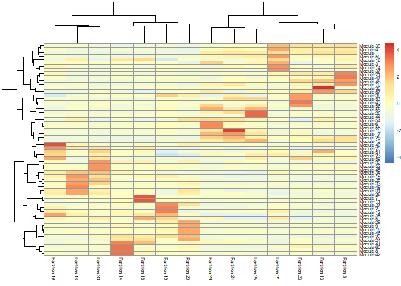

```r
pheatmap::pheatmap(
  agg_mat,
  cluster_rows = TRUE,
  cluster_cols = TRUE,
  scale = "column",
  clustering_method = "ward.D2",
  fontsize = 6
)
```

Some modules are highly specific to certain partitions of cells, while others are shared across multiple partitions. Note that aggregate_gene_expression can work with arbitrary groupings of cells and genes. You’re not limited to looking at modules from find_gene_modules(), clusters(), and partitions().

The second way of looking at modules and their expression is to pass gene_module_df directly to plot_cells(). If there are many modules, it can be hard to see where each one is expressed, so we’ll just look at a subset of them:

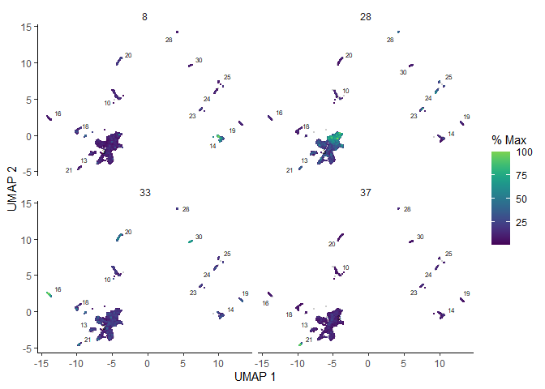

```r
plot_cells(neurons_cds,
           genes=gene_module_df %>% filter(module %in% c(8, 28, 33, 37)),
           group_cells_by="partition",
           color_cells_by="partition",
           show_trajectory_graph=FALSE)
```